# NN_GD slides

## Machine Learning for Engineering

## Neural Networks: Gradient Descent

### Instructor: Daning Huang

## TODAY: Neural Networks - II

- Loss functions
- Newton-type methods
- Gradient descent methods

### References

- PRML Chp. 5
- Referenced papers

## Training Neural Networks

Repeat until convergence

- $(\textbf{x},\textbf{y}) \leftarrow$ Sample an example (or a mini-batch) from data
- $\hat{\textbf{y}} \leftarrow f\left( \textbf{x} ; \theta \right)$ Forward propagation
- Compute $\mathcal{L}\left(\textbf{y},\hat{\textbf{y}}\right)$
- $\nabla_{\theta}\mathcal{L} \leftarrow$ Backward propagation
- Update weights using (stochastic) gradient descent
  - $\theta \leftarrow \theta - \alpha \nabla_{\theta}\mathcal{L}$

### Types of Losses: Squared Loss

$$ \mathcal{L}\left(\textbf{y},\hat{\textbf{y}}\right) = \frac{1}{2}\left\Vert \textbf{y}-\hat{\textbf{y}}\right\Vert^2_2 $$ $$ \frac{\partial\mathcal{L}}{\partial \hat{y}_i}=\hat{y}_i-y_i \iff \nabla_{\hat{\textbf{y}}}\mathcal{L}=\hat{\textbf{y}}-\textbf{y} $$

- Used for regression problems

### Forward/Backward propagation

[figure not shown]

We are going to cover backward propagation in the next lecture.

## Newton's Method: Overview

- **Goal:** Minimize a general function $F(w)$ in one dimension by solving for $$ f(w) = \frac{\partial F}{\partial w} = 0 $$
- **Newton's Method:** To find roots of $f$, Repeat until convergence: $$ w \leftarrow w - \frac{f(w)}{f'(w)} $$

### Geometric Intuition

- Find the roots of $f(w)$ by following its **tangent lines**. The tangent line to $f$ at $w_{k-1}$ has equation $$ \ell(w) = f(w_{k-1}) + (w-w_{k-1}) f'(w_{k-1}) $$
- Set next iterate $w$ to be **root** of tangent line: $$ \begin{align*} f(w_{k-1}) + (w-w_{k-1}) f'(w_{k-1}) = 0 \\ \Rightarrow \boxed{ w = w_{k-1} - \frac{f(w_{k-1})}{f'(w_{k-1})} } \end{align*} $$

### Application to minimization

To minimize $F(w)$, find roots of $F'(w)$ via Newton's Method.

**Repeat until convergence**: $$ \boxed{w \leftarrow w - \frac{F'(w)}{F''(w)}} $$

### Minimization in multivariate case

Replace second derivative with the **Hessian Matrix**, $$ H_{ij}(w) = \frac{\partial^2 F}{\partial w_i \partial w_j} $$

Newton update becomes: $$ \boxed{ w \leftarrow w - H^{-1} \nabla_w F} $$

- Advantage: Fast convergence (quadratic)
- Disadvantage: Computing Hessian and its inverse is slow

### Sometimes line search is necessary

Let $p=-H^{-1} \nabla_w F$, find a step size $\alpha$ such that $$ \min_\alpha F(w+\alpha p) $$ Then $$ \boxed{ w \leftarrow w - \alpha H^{-1} \nabla_w F} $$

### Issues

- Computing Hessian is expensive
  - Approximate linear solve for $H^{-1}$
  - Quasi-Newton methods: Construct approximate $H$ from past gradients (e.g. **BFGS** using secant equation) $$\mbox{Scalar:}\quad F''(w_{k+1}) \approx [F'(w_{k+1}) - F'(w_k)]/(w_{k+1}-w_k)$$ $$\mbox{Vector:}\quad H_{k+1}(w_{k+1}-w_k) \approx \nabla_w F(w_{k+1}) - \nabla_w F(w_k)$$
- Do not work well for non-convex problems
  - It only solves for $\nabla_w F=0$
  - The solution can be a saddle point, or even a maximizer!
  - Possible to use the **Levenberg-Marquardt** algorithm (regularizing the Hessian) $$\tilde{H} = \lambda I + H,\quad \lambda>0$$

### Unfortunately, saddle points prevail in high dimensions

The $\epsilon-\alpha$ curve [1]

- $\alpha$: Percentage of negative eigenvalues of Hessian at critical point (i.e. gradient=0)
- $\epsilon$: Error at critical point
- There are many saddle points (the figure is for a relatively small NN)
- Strong positive correlation between $\alpha$ and $\epsilon$, esp. in high-dim optimization

[figure not shown]

[1] Y. Dauphin et al. Identifying and attacking the saddle point problem in high-dimensional non-convex optimization. NeurIPS 2014.

> Intuitively, in high dimensions, the chance that all the directions around a critical point lead upward (positive curvature) is exponentially small w.r.t. the number of dimensions

Implications:

- If you get a "converged" model and it does not perform well, then the model is likely at a saddle point
- The local minima are likely to be as good as global minima
  - For even larger problems, even saddle points with low index are sufficient (which is more common)
- Now that Hessian-based method might be problematic, we should just use **Gradient Descent**

## Simple Gradient Descent

### Batch mode

Given dataset $\{ (x,t) \}$ and initial guess $\theta_0$, repeat until convergence:

- $\theta = \theta - \eta \nabla_\theta \mathcal{L}(\theta)$

where $\eta$ is the step size(s), or **learning rate**, and assuming quadratic loss,

$$ \nabla_\theta \mathcal{L}(\theta) = \sum_{n=1}^N \left[ f\left( \textbf{x}^{(n)} ; \theta \right) - y^{(n)} \right] \frac{\partial f\left( \textbf{x}^{(n)} ; \theta \right)}{\partial \theta} $$

- Disadvantage: Can be slow if the network is large and the dataset is huge

### Stochastic mode, a.k.a., Stochastic Gradient Descent (SGD)

**Main Idea:** Instead of computing batch gradient (over entire training data), just compute gradient for individual example and update.

**Repeat** until convergence: for $n=1,\dots,N$

$$ \theta = \theta - \eta \nabla_\theta \mathcal{L}(\textbf{x}^{(n)}; \theta) $$

where

$$ \nabla_\theta \mathcal{L}(\textbf{x}^{(n)}; \theta) = \left[ f\left( \textbf{x}^{(n)} ; \theta \right) - y^{(n)} \right] \frac{\partial f\left( \textbf{x}^{(n)} ; \theta \right)}{\partial \theta} $$

- Advantage: Easier to compute, esp. when the dataset is huge; sometimes can escape local minima
- Disadvantage: The gradient becomes **noisy** - impacts convergence; the Hessian is **not** well-defined even if we want to use it

> In between there are "mini-batch" mode

### Comparison - Batch mode seems more reliable?

[figure not shown]

### Comparison - but if we look at cost

- Think LBFGS as batch GD
- SGD shows fast initial progress, though slowed down later.

[figure not shown]

Let $n$ be the batch size, $\epsilon\sim 10^{-3}$ the final "loss", $T$ the allowable time, then [1]

- Batch: Work$\sim n\log(1/\epsilon)$, Error$\sim(\log(T)+1)/T$ - better to focus on a certain number of samples
- Stochastic: Work$\sim 1/\epsilon$, Error$\sim 1/T$ - just process as many samples as possible

[1] L. Bottou, et al. Stochastic Gradient Methods For Large-Scale Machine Learning. Arxiv: 1606.04838; Also here as slides: http://users.iems.northwestern.edu/~nocedal/ICML

## Practical SGD methods

$$ \theta = \theta - \eta \nabla_\theta \mathcal{L}(\textbf{x}^{(n)}, \theta) $$

[figure not shown]

- How to determine learning rate?
- How to improve convergence rate?
- Getting out of saddle points?

### Fancier variants

[figure not shown]

### SGD with momentum

Let the optimizer remember the previous gradients, $$ v_k = \rho v_{k-1} + (1-\rho)\nabla_\theta F(\theta_k) $$ Then $$ \boxed{ \theta_{k+1} = \theta_k - \eta v_k} $$

- Momentum is a weighted sum of gradients, weights for old gradients decay exponentially
- Less sensitive to noise
- Easier to pass local minimum

### AdaGrad

Let the optimizer tune learning rate automatically, $$ g_k = g_{k-1} + [\nabla_\theta F(\theta_k)]^2 $$ Then $$ \boxed{ \theta_{k+1} = \theta_k - \frac{\eta}{\sqrt{g_k}+\epsilon} \nabla_\theta F(\theta_k)} $$

- Note that the square and sqrt are *element-wise*, $\epsilon\sim 10^{-6}$ to avoid division by zero
- Learning rate decreases as the solution moves longer distance
- Now $\eta$ can be very large - It will become small anyways

### RMSProp

Similar to AdaGrad, but allow the optimizer to "forget", $$ g_k = \alpha g_{k-1} + (1-\alpha)[\nabla_\theta F(\theta_k)]^2 $$ Then $$ \boxed{ \theta_{k+1} = \theta_k - \frac{\eta}{\sqrt{g_k}+\epsilon} \nabla_\theta F(\theta_k)} $$

- Like momentum, let old squared gradient decay exponentially. Typically $\alpha=0.9$.
- The rest is AdaGrad.

### Adam

Combine the best of SGD w/ momentum and RMSProp, $$v_k = \beta_1 v_{k-1} + (1-\beta_1)\nabla_\theta F(\theta_k)$$ $$g_k = \beta_2 g_{k-1} + (1-\beta_2)[\nabla_\theta F(\theta_k)]^2$$ Then $$ \boxed{ \theta_{k+1} = \theta_k - \frac{\eta}{\sqrt{g_k}+\epsilon} v_k} $$

- Sometimes $v_k$ and $g_k$ are corrected before updating $\theta$, $$ v_k \leftarrow \frac{v_k}{1-\beta_1^k},\quad g_k \leftarrow \frac{g_k}{1-\beta_2^k} $$
- It was suggested to use $\beta_1=0.9$, $\beta_2=0.999$.

### More methods

People have devised many, many other gradient-descent methods. Some perform the best in some specific applications, but there is not "one-for-all" solution.

> You will implement one of them in HW3.

There are also attempts to combine the advantages of different methods, e.g. [1]

[1] N. Keskar, R. Socher, Improving Generalization Performance by Switching from Adam to SGD, Arxiv 1712.07628

### Visual comparison of the methods - I

From https://ruder.io/optimizing-gradient-descent/:

[figure not shown]

### Visual comparison of the methods - II

From ruder.io:

[figure not shown]

Again, Deep NN's are filled with saddle points

## Interactive Examples

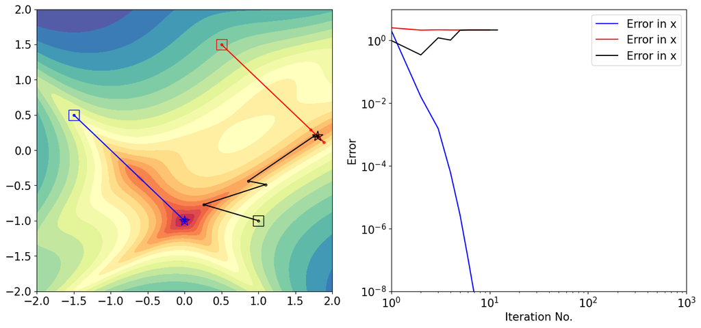

```python
xs = [[-1.5,0.5], [0.5, 1.5], [1.0, -1.0]]
res = batch_gradDesc(FGH, xs, NR(0.0), ifLS=True)  # Non-zero parameter for Levenberg-Marquardt
f1, ax = pltFunc(); batch_pltRes(ax, res)
```

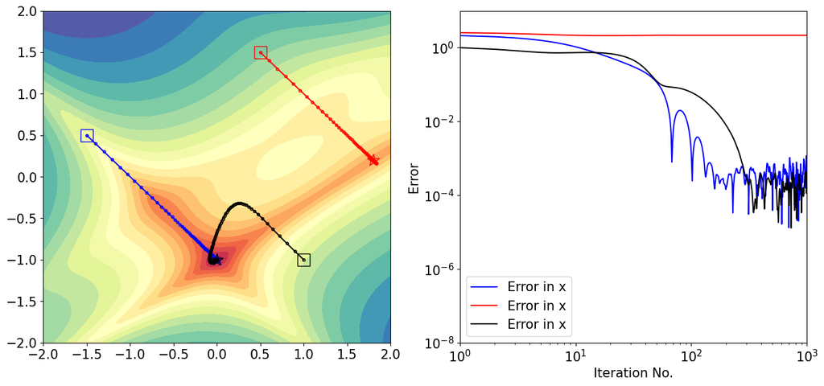

```python
xs = [[-1.5,0.5], [0.5, 1.5], [1.0, -1.0]]
ss = 0.5  # Noise in gradient

# res = batch_gradDesc(FGHS(ss), xs, fixLR(0.00001))
# res = batch_gradDesc(FGHS(ss), xs, GDM(0.00001,0.9))
# res = batch_gradDesc(FGHS(ss), xs, AdaGrad(2.0))
# res = batch_gradDesc(FGHS(ss), xs, RMSProp(0.1,0.9))
res = batch_gradDesc(FGHS(ss), xs, Adam(0.1,0.9,0.999))
f1, ax = pltFunc(); batch_pltRes(ax, res)
```

One more awesome interactive visualization: https://github.com/lilipads/gradient_descent_viz

### Now that we know there are many saddle points and local minima...

- What kind of local minima is better? The **flat** ones - (empirically) better generalization performance
- Compare Adam and vanilla SGD [1]
  - Adam escapes saddle point easier (see the GIF earlier)
  - SGD favors flat minima more

> Additional conclusion from [1]: A small learning rate or large-batch makes it much harder to escape from sharp minima

[1] Z. Xie. A Diffusion Theory For Deep Learning Dynamics: Stochastic Gradient Descent Exponentially Favors Flat Minima. Arxiv: 2002.03495

### ... And after all there are not that many local minima

Say we have trained a NN and then permute two neurons in a fully-connected layer

- The model parameters change from $\Theta_A$ to $\Theta_B$
- But the model output does **not** change and is "functionally equivalent"
- Even a simple MLP with 3 layers and 512 width has $10^{3498}$ equivalent permutations
  - Namely $(512!)^3$, ! for factorial

[1] S. Ainsworth et al. Git Re-Basin: Merging Models modulo Permutation Symmetries. ICLR 2023.

**Linear mode connectivity**

- One can permute $\Theta_B'=\pi(\Theta_B)$ so $\Theta_A$ and $\Theta_B'$ are in the same basin
- Varying parameters $\Theta(\lambda)=(1-\lambda)\Theta_A+\lambda\Theta_B$ experiences a bump in loss
- ... but $\Theta_A\rightarrow\Theta_B'$ does not!

[figure not shown]

**Further take-away**

- Left: SGD favors one of the equivalent models during training
- Right: A wider model has more permutations and is easier for SGD to find better model

> One possible intuition: SGD somewhat moves randomly; when there are many equivalent basins, it is more likely for it to hit one basin.

[figure not shown]

## Practical aspects in training

- General procedure
- Techniques for improved convergence and better solutions

### Basics: General procedure

- If there are not much data - try cross-validation to use all data
  - i.e., do splits of train-test, so that all data points are used as test once.
  - See Linear Regression module for review.
- Otherwise, do a split of train-valid-test.
  - Train: for decreasing the loss
  - Valid: for picking the best parameter during training (behave like in CV)
  - Test: *Completely* unseen in the training process, used to verify the model performance

### Basics: Diagnose your loss curve

[figure not shown]

- Linearly decrease: increase the learning rate
- Shaky curves: increase the batch size
- Distant train/valid curves: overfitting
- Overlapping train/valid curves: underfitting

### Basics: More on loss curves

dev=valid

[figure not shown]

[1] A. Ng, Nuts and Bolts of Building Applications using Deep Learning, NeurIPS 2016

### Intermediate: Caveats and Tuning tricks - I

- Always **normalize** and **shuffle** your data!
  - But normalization factors should be based on **training** dataset only.
- Pick the right learning rate: e.g., Grid search [1], or (cyclic) scheduling [2,3]
  - Higher learning rate for larger batch size (and larger batch-size if you have a bigger machine)

[1] S. Gugger, How Do You Find A Good Learning Rate

[2] I. Loshchilov, SGDR: Stochastic gradient descent with warm restarts, Arxiv: 1608.03983

[3] L. Smith, Cyclical Learning Rates for Training Neural Networks, 2017

### Intermediate: Caveats and Tuning tricks - II

- Pick the right optimizer: Typically start with Adam, fine-tune with SGD
- Start with ReLU or tanh for activation; avoid sigmoid unless for "gate"-like layers
- Try overfitting on a small dataset
  - If your code/model is correct, the training should converge really fast
- Record your training experiments - learn from history

### More techniques

[figure not shown]

[1] R. Sun. Optimization for deep learning: theory and algorithms. Arxiv 1912.08957 *A nice comprehensive summary*

### More techniques - Weight initialization

- Basically to get better initial guesses of the weights [1,2]
- Let $n_i$ be input size, $n_o$ output size, so the weight $W$ of size $(n_i,n_o)$ and let $n=n_i$ or $n=(n_i+n_o)/2$
- Uniform $U[-s,s]$
  - Xavier (tanh/sigmoid): $s=\sqrt{3/n}$
  - Kaiming (ReLU): $s=\sqrt{6/n}$
- Gaussian $N(0,\sigma^2)$
  - Xavier (tanh/sigmoid): $\sigma=\sqrt{1/n}$
  - Kaiming (ReLU): $\sigma=\sqrt{2/n}$

[1] X. Glorot, et al. Understanding the difficulty of training deep feedforward neural networks. AISTATS 2010

[2] K. He, et al. Delving Deep into Rectifiers: Surpassing Human-Level Performance on ImageNet Classification. 1502.01852

### More techniques - Dropout

- Randomly "throw away" neurons during training
  - so these neuron do not contribute to the prediction and their weights are not updated.
  - This is as if multiple NNs are being learned during training
- Avoids overfitting, since now there is a "committee" of NNs

[1] G. Hinton, et al. Improving neural networks by preventing co-adaptation of feature detectors. Arxiv:1207.0580

### More techniques - Normalization within Network - I

- If we think each NN layer is a small model that we want to fit
  - Then it is natural to think about normalizing the "inputs" to these layers
  - The inputs, however, are the outputs of the preceeding layer
- Batch Normalization [1] does the trick
  - Turns out it maintains the distribution of inputs/outputs of the NN layers
  - Leads to faster convergence and perhaps better accuracy

[figure not shown]

[1] S. Ioffe, et al. Batch normalization: Accelerating deep network training by reducing internal covariate shift. ICML 2015.

### More techniques - Normalization within Network - II

[figure not shown]

- There are more variants, too, such as weight/layer/instance/group normalization etc.
  - See weight normalization [2] for example, it reparametrizes the weights instead of the inputs.

[2] T. Salimans, et al. Weight normalization: A simple reparameterization to accelerate training of deep neural networks. NeurIPS 2016

> Nowadays, there are more strategies to normalize, see e.g. [here](https://tungmphung.com/deep-learning-normalization-methods/).

### More techniques - Skip connection

[figure not shown]

- This is an important type of NN architecture. It improves the convergence and has deeper implications.
- We will come back to this when talking about NN architectures.

### Pursuing zero training error?

[figure not shown]

BTW, look at that deep-double descent!

[1] T. Ishida, et al. Do We Need Zero Training Loss After Achieving Zero Training Error? Arxiv: 2002.08709